# Sixth Week: Linear Models

House price prediction

Erfan Hosseini _ 93101373

2018-04-12 17:21:42

> با توجه به داده های قیمت منازل لطفا با سوالات زیر پاسخ دهید.

```r
rm(list = ls())
path = '~/R/HW6/hw_06/'
library(readr)
library(dplyr)
library(highcharter)
house = read_csv(paste(path, 'train.csv', sep = '/' ))
house %>% select(-Alley) -> house
```

۱. ماتریس همبستگی متغیرهای مختلف را به دست آورده و سپس رسم نمایید. اعداد به دست آمده را با آزمون فرض معناداری همبستگی بسنجید و سپس ده متغیری که همبستگی بالاتری با قیمت دارند را مشخص نمایید.

The corelation between sale price and all other features are calculated here:

```r
cors = as.data.frame(integer(80))
cors$cor = 0
cors %>% select(cor) -> cors
cors$pVal = 0
colnames(house)[43] = 'firstflrsf'
for(i in 2:79){
    house %>% select(SalePrice, i) %>% na.omit() -> tmp
    if ( lapply(tmp[1, 2], class) == 'character'){
        tmp['pox'] = as.numeric(as.factor(as.matrix(tmp[, 2])))
    }else{
        tmp['pox'] = tmp[,2]
    }
    test = cor.test(tmp$SalePrice, tmp$pox)
    cors$cor[i] =  test$estimate
    cors$pVal[i] = test$p.value

}
cors %>% mutate(colNum = row_number()) %>% filter(pVal <= 0.05) %>%
    filter(colNum != 62 & colNum != 49 & colNum != 62 & colNum != 54 & colNum != 59 & colNum != 30 & colNum != 60) %>%
    arrange(desc(abs(cor))) -> cors
cors$ColName = colnames(house)[cors$colNum]
print(cors)
```

```
##            cor          pVal colNum       ColName
## 1   0.79098160 2.185675e-313     17   OverallQual
## 2   0.70862448 4.518034e-223     46     GrLivArea
## 3   0.64040920 2.498644e-169     61    GarageCars
## 4  -0.63688369 6.424468e-167     27     ExterQual
## 5   0.61358055 9.484229e-152     38   TotalBsmtSF
## 6   0.60585218 5.394711e-147     43    firstflrsf
## 7  -0.58918878 3.559116e-137     53   KitchenQual
## 8   0.52289733 2.990229e-103     19     YearBuilt
## 9   0.50710097  3.164948e-96     20  YearRemodAdd
## 10  0.47749305  1.458509e-83     26    MasVnrArea
## 11  0.46692884  6.141487e-80     56    Fireplaces
## 12 -0.40017754  2.898928e-57     40     HeatingQC
## 13  0.38641981  3.394110e-53     34    BsmtFinSF1
## 14  0.38247899  4.579866e-52     29    Foundation
```

[output cut: 43 more lines]

The 10 most corelated features with sale price is listed below. Some features are deleted due to high number of NaN.

```r
cors %>% head(10) -> topCors
print(topCors)
```

```
##           cor          pVal colNum      ColName
## 1   0.7909816 2.185675e-313     17  OverallQual
## 2   0.7086245 4.518034e-223     46    GrLivArea
## 3   0.6404092 2.498644e-169     61   GarageCars
## 4  -0.6368837 6.424468e-167     27    ExterQual
## 5   0.6135806 9.484229e-152     38  TotalBsmtSF
## 6   0.6058522 5.394711e-147     43   firstflrsf
## 7  -0.5891888 3.559116e-137     53  KitchenQual
## 8   0.5228973 2.990229e-103     19    YearBuilt
## 9   0.5071010  3.164948e-96     20 YearRemodAdd
## 10  0.4774930  1.458509e-83     26   MasVnrArea
```

۲. در یک تصویر نمودار پراکنش دو به دو ده متغیر بدست آمده به همراه قیمت را رسم نمایید و هم خطی بودن متغیرها را بررسی کنید

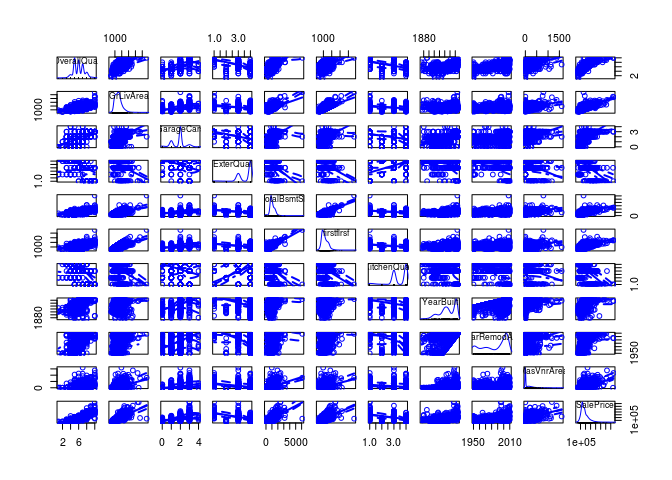

```r
house %>% select(OverallQual, GrLivArea, GarageCars, ExterQual, TotalBsmtSF, firstflrsf, KitchenQual, YearBuilt, YearRemodAdd, MasVnrArea, SalePrice) -> tenMos
tenMos$KitchenQual = as.numeric(as.factor(tenMos$KitchenQual))
tenMos$ExterQual = as.numeric(as.factor(tenMos$ExterQual))
tenMos %>% na.omit() -> tenMos
car::scatterplotMatrix(tenMos)
```

۳. یک مدل خطی بر اساس ده متغیر برای پیش بینی قیمت برازش دهید. و سپس خلاصه نتایج مدل را به دست آورید.

```r
fit = lm(data=tenMos, SalePrice ~ OverallQual + GrLivArea + GarageCars + ExterQual + TotalBsmtSF + firstflrsf + KitchenQual + YearBuilt + YearRemodAdd+ MasVnrArea )
summary(fit)
```

```
##
## Call:
## lm(formula = SalePrice ~ OverallQual + GrLivArea + GarageCars +
##     ExterQual + TotalBsmtSF + firstflrsf + KitchenQual + YearBuilt +
##     YearRemodAdd + MasVnrArea, data = tenMos)
##
## Residuals:
##     Min      1Q  Median      3Q     Max
## -474887  -17989    -800   16576  286697
##
## Coefficients:
##                Estimate Std. Error t value Pr(>|t|)
## (Intercept)  -6.651e+05  1.231e+05  -5.404 7.61e-08 ***
## OverallQual   1.468e+04  1.201e+03  12.221  < 2e-16 ***
## GrLivArea     4.413e+01  2.629e+00  16.784  < 2e-16 ***
## GarageCars    1.302e+04  1.736e+03   7.499 1.12e-13 ***
## ExterQual    -8.708e+03  2.049e+03  -4.250 2.28e-05 ***
## TotalBsmtSF   1.695e+01  4.066e+00   4.167 3.27e-05 ***
## firstflrsf    1.292e+01  4.705e+00   2.745  0.00612 **
## KitchenQual  -1.137e+04  1.565e+03  -7.266 6.06e-13 ***
## YearBuilt     1.841e+02  4.653e+01   3.955 8.01e-05 ***
## YearRemodAdd  1.696e+02  6.230e+01   2.722  0.00657 **
## MasVnrArea    3.026e+01  6.084e+00   4.974 7.36e-07 ***
## ---
## Signif. codes:  0 '***' 0.001 '**' 0.01 '*' 0.05 '.' 0.1 ' ' 1
##
## Residual standard error: 36130 on 1441 degrees of freedom
## Multiple R-squared:  0.7938, Adjusted R-squared:  0.7923
## F-statistic: 554.7 on 10 and 1441 DF,  p-value: < 2.2e-16
```

۴. نمودار قیمت واقعی و قیمت پیش بینی را رسم نمایید و خوب بودن مدل را ارزیابی کنید.

```r
predPrice = predict.lm(fit, tenMos)
tenMos %>% select(SalePrice) -> price
price$predPrice = predPrice
hchart(price, hcaes(x = SalePrice, y = predPrice), type = 'scatter') %>%
    hc_yAxis(title = list(text = 'Predicted Price')) %>%
    hc_title(text= 'Predicted Price VS Price') %>%
    hc_xAxis(title = list(text = 'Price'))
```

[interactive chart not shown]

In the best case the chart should became y=x line, so we consider the distance from this line to judge the model. Since the data points are scattered along y=x line with good distance, we can conclude that model is fine.

۵. مقدار R-squared مدل را به دست آورید. آیا بر اساس این کمیت مدل به خوبی به داده ها برازش داده شده است؟ کمیت F-statistic را در خلاصه مدل تفسیر نمایید.

We can see the summary of the model below:

```r
summary(fit)
```

```
##
## Call:
## lm(formula = SalePrice ~ OverallQual + GrLivArea + GarageCars +
##     ExterQual + TotalBsmtSF + firstflrsf + KitchenQual + YearBuilt +
##     YearRemodAdd + MasVnrArea, data = tenMos)
##
## Residuals:
##     Min      1Q  Median      3Q     Max
## -474887  -17989    -800   16576  286697
##
## Coefficients:
##                Estimate Std. Error t value Pr(>|t|)
## (Intercept)  -6.651e+05  1.231e+05  -5.404 7.61e-08 ***
## OverallQual   1.468e+04  1.201e+03  12.221  < 2e-16 ***
## GrLivArea     4.413e+01  2.629e+00  16.784  < 2e-16 ***
## GarageCars    1.302e+04  1.736e+03   7.499 1.12e-13 ***
## ExterQual    -8.708e+03  2.049e+03  -4.250 2.28e-05 ***
## TotalBsmtSF   1.695e+01  4.066e+00   4.167 3.27e-05 ***
## firstflrsf    1.292e+01  4.705e+00   2.745  0.00612 **
## KitchenQual  -1.137e+04  1.565e+03  -7.266 6.06e-13 ***
## YearBuilt     1.841e+02  4.653e+01   3.955 8.01e-05 ***
## YearRemodAdd  1.696e+02  6.230e+01   2.722  0.00657 **
## MasVnrArea    3.026e+01  6.084e+00   4.974 7.36e-07 ***
## ---
## Signif. codes:  0 '***' 0.001 '**' 0.01 '*' 0.05 '.' 0.1 ' ' 1
##
## Residual standard error: 36130 on 1441 degrees of freedom
## Multiple R-squared:  0.7938, Adjusted R-squared:  0.7923
## F-statistic: 554.7 on 10 and 1441 DF,  p-value: < 2.2e-16
```

The R-squared value is: 0.794. R-squared value of 1 means perfect linear modeling and since we are close to 1, it means that the model is good. The F-statistic is 554.7 on 1441 DF which leads to p-value smaller than 2.2e-16. Since the p-value is smaller than 0.05 we can conclude that selected features are good.

۶. بر اساس p-value سطح معناداری ضرایب تصمیم بگیرید که چه متغیرهایی در مدل سازی استفاده شود. بر اساس متغیرهای جدید دوباره مدل سازی کنید و نتایج رو گزارش دهید.

We can see model summary below:

```r
summary(fit)
```

```
##
## Call:
## lm(formula = SalePrice ~ OverallQual + GrLivArea + GarageCars +
##     ExterQual + TotalBsmtSF + firstflrsf + KitchenQual + YearBuilt +
##     YearRemodAdd + MasVnrArea, data = tenMos)
##
## Residuals:
##     Min      1Q  Median      3Q     Max
## -474887  -17989    -800   16576  286697
##
## Coefficients:
##                Estimate Std. Error t value Pr(>|t|)
## (Intercept)  -6.651e+05  1.231e+05  -5.404 7.61e-08 ***
## OverallQual   1.468e+04  1.201e+03  12.221  < 2e-16 ***
## GrLivArea     4.413e+01  2.629e+00  16.784  < 2e-16 ***
## GarageCars    1.302e+04  1.736e+03   7.499 1.12e-13 ***
## ExterQual    -8.708e+03  2.049e+03  -4.250 2.28e-05 ***
## TotalBsmtSF   1.695e+01  4.066e+00   4.167 3.27e-05 ***
## firstflrsf    1.292e+01  4.705e+00   2.745  0.00612 **
## KitchenQual  -1.137e+04  1.565e+03  -7.266 6.06e-13 ***
## YearBuilt     1.841e+02  4.653e+01   3.955 8.01e-05 ***
## YearRemodAdd  1.696e+02  6.230e+01   2.722  0.00657 **
## MasVnrArea    3.026e+01  6.084e+00   4.974 7.36e-07 ***
## ---
## Signif. codes:  0 '***' 0.001 '**' 0.01 '*' 0.05 '.' 0.1 ' ' 1
##
## Residual standard error: 36130 on 1441 degrees of freedom
## Multiple R-squared:  0.7938, Adjusted R-squared:  0.7923
## F-statistic: 554.7 on 10 and 1441 DF,  p-value: < 2.2e-16
```

Since the p-value of all the selected features are smaller than 0.05, we can conclude that all of them are selected properly and should be considered in modeling.

۷. مدل خود را بر اساس باقی مانده نقص یابی کنید. سه محک normality, independance, Constant Variance را در نقص یابی خود در نظر بگیرید.

Four plots of fitted model is shown below:

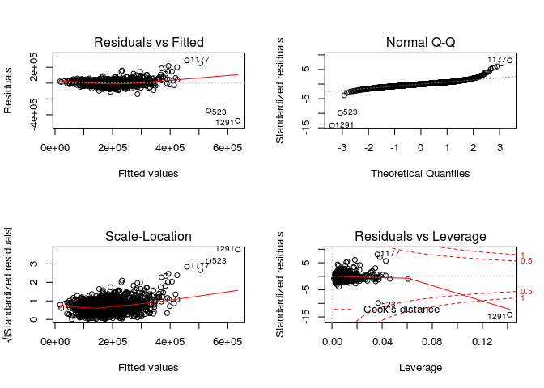

```r
par(mfrow=c(2, 2))
plot(fit)
```

```r
cor.test(tenMos$OverallQual, fit$residuals)
```

```
##
##  Pearson's product-moment correlation
##
## data:  tenMos$OverallQual and fit$residuals
## t = 1.8611e-14, df = 1450, p-value = 1
## alternative hypothesis: true correlation is not equal to 0
## 95 percent confidence interval:
##  -0.05144348  0.05144348
## sample estimates:
##          cor
## 4.887361e-16
```

```r
cor.test(tenMos$GrLivArea, fit$residuals)
```

```
##
##  Pearson's product-moment correlation
##
## data:  tenMos$GrLivArea and fit$residuals
## t = -2.649e-15, df = 1450, p-value = 1
## alternative hypothesis: true correlation is not equal to 0
## 95 percent confidence interval:
##  -0.05144348  0.05144348
## sample estimates:
##           cor
## -6.956545e-17
```

```r
cor.test(tenMos$GarageCars, fit$residuals)
```

```
##
##  Pearson's product-moment correlation
##
## data:  tenMos$GarageCars and fit$residuals
## t = 9.9197e-15, df = 1450, p-value = 1
## alternative hypothesis: true correlation is not equal to 0
## 95 percent confidence interval:
##  -0.05144348  0.05144348
## sample estimates:
##          cor
## 2.605048e-16
```

```r
cor.test(tenMos$ExterQual, fit$residuals)
```

```
##
##  Pearson's product-moment correlation
##
## data:  tenMos$ExterQual and fit$residuals
## t = 3.8552e-14, df = 1450, p-value = 1
## alternative hypothesis: true correlation is not equal to 0
## 95 percent confidence interval:
##  -0.05144348  0.05144348
## sample estimates:
##          cor
## 1.012429e-15
```

```r
cor.test(tenMos$TotalBsmtSF, fit$residuals)
```

```
##
##  Pearson's product-moment correlation
##
## data:  tenMos$TotalBsmtSF and fit$residuals
## t = -3.8419e-15, df = 1450, p-value = 1
## alternative hypothesis: true correlation is not equal to 0
## 95 percent confidence interval:
##  -0.05144348  0.05144348
## sample estimates:
##           cor
## -1.008939e-16
```

```r
cor.test(tenMos$firstflrsf, fit$residuals)
```

```
##
##  Pearson's product-moment correlation
##
## data:  tenMos$firstflrsf and fit$residuals
## t = -6.409e-15, df = 1450, p-value = 1
## alternative hypothesis: true correlation is not equal to 0
## 95 percent confidence interval:
##  -0.05144348  0.05144348
## sample estimates:
##          cor
## -1.68308e-16
```

```r
cor.test(tenMos$KitchenQual, fit$residuals)
```

```
##
##  Pearson's product-moment correlation
##
## data:  tenMos$KitchenQual and fit$residuals
## t = 2.6522e-14, df = 1450, p-value = 1
## alternative hypothesis: true correlation is not equal to 0
## 95 percent confidence interval:
##  -0.05144348  0.05144348
## sample estimates:
##          cor
## 6.965024e-16
```

```r
cor.test(tenMos$YearBuilt, fit$residuals)
```

```
##
##  Pearson's product-moment correlation
##
## data:  tenMos$YearBuilt and fit$residuals
## t = 3.0233e-15, df = 1450, p-value = 1
## alternative hypothesis: true correlation is not equal to 0
## 95 percent confidence interval:
##  -0.05144348  0.05144348
## sample estimates:
##          cor
## 7.939478e-17
```

```r
cor.test(tenMos$YearRemodAdd, fit$residuals)
```

```
##
##  Pearson's product-moment correlation
##
## data:  tenMos$YearRemodAdd and fit$residuals
## t = -2.9175e-14, df = 1450, p-value = 1
## alternative hypothesis: true correlation is not equal to 0
## 95 percent confidence interval:
##  -0.05144348  0.05144348
## sample estimates:
##           cor
## -7.661826e-16
```

```r
cor.test(tenMos$MasVnrArea, fit$residuals)
```

```
##
##  Pearson's product-moment correlation
##
## data:  tenMos$MasVnrArea and fit$residuals
## t = -2.8178e-15, df = 1450, p-value = 1
## alternative hypothesis: true correlation is not equal to 0
## 95 percent confidence interval:
##  -0.05144348  0.05144348
## sample estimates:
##           cor
## -7.399814e-17
```

All the p-values are 1 which states that we can accept the null hypothesis of independancy.

۸. داده ها را به پنج قسمت تقسیم کنید. بر اساس چهار قسمت مدل خطی را بسازید و صحت مدل را برای یک قسمت باقی مانده را تست کنید. خطای پیش بینی شما چقدر است؟

We split the data set into 2 random groups, one with size 0.8 of the data set and the other with size 0.2, then train the model based on the larger group and predict the prices over the smaller group and messure the mean square error.

```r
trainIdx = sample(nrow(house), 1168)
testIdx = setdiff(c(1:1460), trainIdx)
train = house[trainIdx, ]
test = house[testIdx, ]
fit = lm(data=train, SalePrice ~ OverallQual + GrLivArea + GarageCars  + TotalBsmtSF + firstflrsf  + ExterQual + KitchenQual+ BsmtQual )
predPrice = predict.lm(fit, test)
test %>% select(SalePrice) -> price
price$predPrice = predPrice
price %>% mutate(error = (SalePrice - predPrice)^2) -> price
print(sqrt(mean(price$error, na.rm = T)))
```

```
## [1] 32223.92
```

۹. آیا قیمت ربط غیر خطی با یکی از ده متغیر استفاده شده دارد؟ بر اساس دستاوردهای خود مدل را بهتر نمایید.

For choosing the right power of features, we calculate the corelation of sale price with different powers of features and select the power with the highest corelation.

```r
topCors$power = 0
cor(house$SalePrice, house$OverallQual)
```

```
## [1] 0.7909816
```

```r
cor(house$SalePrice, house$OverallQual^2)
```

```
## [1] 0.8171684
```

```r
cor(house$SalePrice, house$OverallQual^3)
```

```
## [1] 0.8252378
```

```r
cor(house$SalePrice, house$OverallQual^4)
```

```
## [1] 0.8190695
```

```r
topCors$power[1] = 3
cor(house$SalePrice, house$GrLivArea)
```

```
## [1] 0.7086245
```

```r
cor(house$SalePrice, house$GrLivArea^2)
```

```
## [1] 0.6522667
```

```r
cor(house$SalePrice, house$GrLivArea^3)
```

```
## [1] 0.5157869
```

```r
cor(house$SalePrice, house$GrLivArea^4)
```

```
## [1] 0.3541535
```

```r
topCors$power[2] = 1
cor(house$SalePrice, house$GarageCars)
```

```
## [1] 0.6404092
```

```r
cor(house$SalePrice, house$GarageCars^2)
```

```
## [1] 0.6713941
```

```r
cor(house$SalePrice, house$GarageCars^3)
```

```
## [1] 0.646082
```

```r
cor(house$SalePrice, house$GarageCars^4)
```

```
## [1] 0.5954278
```

```r
topCors$power[3] = 2
topCors$power[4] = 1 # determined from the chart
cor(house$SalePrice, house$TotalBsmtSF)
```

```
## [1] 0.6135806
```

```r
cor(house$SalePrice, house$TotalBsmtSF^2)
```

```
## [1] 0.4790823
```

```r
cor(house$SalePrice, house$TotalBsmtSF^3)
```

```
## [1] 0.22298
```

```r
cor(house$SalePrice, house$TotalBsmtSF^4)
```

```
## [1] 0.07919038
```

```r
topCors$power[5] = 1
cor(house$SalePrice, house$firstflrsf)
```

```
## [1] 0.6058522
```

```r
cor(house$SalePrice, house$firstflrsf^2)
```

```
## [1] 0.5489903
```

```r
topCors$power[6] = 1
topCors$power[7] = 1 # determined from the chart
topCors$power[8] = 1 # determined from the chart
topCors$power[9] = 1 # determined from the chart
topCors$power[10] = 1 # determined from the chart
```

We can see the table of features and their chosen powers below:

```r
print(topCors)
```

```
##           cor          pVal colNum      ColName power
## 1   0.7909816 2.185675e-313     17  OverallQual     3
## 2   0.7086245 4.518034e-223     46    GrLivArea     1
## 3   0.6404092 2.498644e-169     61   GarageCars     2
## 4  -0.6368837 6.424468e-167     27    ExterQual     1
## 5   0.6135806 9.484229e-152     38  TotalBsmtSF     1
## 6   0.6058522 5.394711e-147     43   firstflrsf     1
## 7  -0.5891888 3.559116e-137     53  KitchenQual     1
## 8   0.5228973 2.990229e-103     19    YearBuilt     1
## 9   0.5071010  3.164948e-96     20 YearRemodAdd     1
## 10  0.4774930  1.458509e-83     26   MasVnrArea     1
```

۱۰. بر اساس مدل نهایی به دست آمده نتایج پیش بینی خود را بر روی test.csv به دست آورید و در سایت kaggle در مسابقه House Prices: Advanced Regression Techniques بارگذاری نمایید. سپس لینک رتبه و عدد آن را ضمیمه تمرین کنید.

For this part we train the model based on the selected features and chosen powers and then predict the prices of the test set.

```r
fit = lm(data=house, SalePrice ~ I(OverallQual^3) + GrLivArea + I(GarageCars^2) + ExterQual + TotalBsmtSF + firstflrsf + KitchenQual + YearBuilt + YearRemodAdd )
summary(fit)
```

```
##
## Call:
## lm(formula = SalePrice ~ I(OverallQual^3) + GrLivArea + I(GarageCars^2) +
##     ExterQual + TotalBsmtSF + firstflrsf + KitchenQual + YearBuilt +
##     YearRemodAdd, data = house)
##
## Residuals:
##     Min      1Q  Median      3Q     Max
## -481649  -16623    -430   14107  234805
##
## Coefficients:
##                    Estimate Std. Error t value Pr(>|t|)
## (Intercept)      -7.473e+05  1.325e+05  -5.640 2.04e-08 ***
## I(OverallQual^3)  1.422e+02  9.959e+00  14.279  < 2e-16 ***
## GrLivArea         4.508e+01  2.472e+00  18.235  < 2e-16 ***
## I(GarageCars^2)   4.202e+03  4.865e+02   8.639  < 2e-16 ***
## ExterQualFa      -3.453e+04  1.239e+04  -2.788  0.00537 **
## ExterQualGd      -1.815e+04  6.315e+03  -2.874  0.00411 **
## ExterQualTA      -1.944e+04  7.138e+03  -2.724  0.00653 **
## TotalBsmtSF       1.531e+01  3.897e+00   3.928 8.95e-05 ***
## firstflrsf        8.709e+00  4.505e+00   1.933  0.05341 .
## KitchenQualFa    -3.519e+04  8.116e+03  -4.335 1.56e-05 ***
## KitchenQualGd    -2.676e+04  4.684e+03  -5.713 1.35e-08 ***
## KitchenQualTA    -3.385e+04  5.335e+03  -6.344 2.99e-10 ***
## YearBuilt         2.589e+02  4.459e+01   5.805 7.90e-09 ***
## YearRemodAdd      1.601e+02  6.363e+01   2.516  0.01198 *
## ---
## Signif. codes:  0 '***' 0.001 '**' 0.01 '*' 0.05 '.' 0.1 ' ' 1
##
## Residual standard error: 34770 on 1446 degrees of freedom
## Multiple R-squared:  0.8102, Adjusted R-squared:  0.8085
## F-statistic: 474.7 on 13 and 1446 DF,  p-value: < 2.2e-16
```

```r
houseTest = read_csv(paste(path, 'test.csv', sep = '/' ))
houseTest %>% select(-Alley) -> houseTest
colnames(houseTest)[43] = 'firstflrsf'
SalePrice = predict.lm(fit,houseTest)
houseTest %>% select(Id) -> price
price$SalePrice = SalePrice
price$SalePrice[which(is.na(price$SalePrice) == T)] = mean(price$SalePrice, na.rm = T)
write_csv(price, paste(path, 'res.csv', sep = '/' ))
```

This submission at Kaggle website is ranked 3013 with loss of 0.17071. The link to the submission: https://www.kaggle.com/erfan2108/competitions